# Scentre Case Study

2022-06-06

## Question 1: **Healthy Product Groups**:

- Which products can be labelled as **healthy**?
- Create 150-250 **Healthy** product groups concentrating on customer purchasing history

## Grouping based on

- Customer purchasing history
- Existing Category Hierarchy
- NLP on product name/description

## Category Membership Ranking

How much does each product belong to a specific category (like *Health* for example?)

Are there some product groups we are confident they belong to a category?

- Yes: Supervised Learning (Label is required)
  - Binary Classification
  - Metric Regression (Metric Learning)
  - Metric Classification Large Margin nearest neighbors (`pylmnn` package)
- No:
  - Topic Modelling
  - Ranking based on similarities (Multi-dimensional scaling)

## Product Grouping

Which Category does each product belong to?

### We don’t know categories, tell us what categories can be?

- Non-supervised learning
  - K-Means Clustering
  - Metric-based Clustering

### We know which categories we are looking for

Multi-class Classification (labels are required)

## Combined iterative non-supaervised-supervised learning

1- Run non-supervised grouping on similarities

2- Update membership labels

3- Run supervised learning

4- Update feature weights

5- Repeat from 1

## Suggessted Product Features:

- *ProductPopularity* (Cumulative Total Product Purchase Frequency)
- *Product Purchase Frequency* (mean/median/max)
- *Customer Product Purchase Rate* (what percentage of customers purchased this product recently)
- *Average Amount per Purchase*
- *Unit Price*

## Question 2: **Customer Needs**:

- What analysis would you perform to identify customer broader needs?
- What other customer need categories? Examples:
  - Party
  - Outdoor
  - Travel
  - Baby

## Suggested combined product similarities for metric clustering:

1- NLP-based metrics: Product Name/Product Description similarities

- Hemming(Binary)
- Cosine dissimilarity (Spherical),
- Minkovski, Canberra, …

2- Co-purchase rate (Hemming metric for customer purchases)

3- Common Depth in the Existing Department/Hierarchy

## Question 3: Customer Segments:

- Methodology
- Benefits
- Focus on customer product choice not RFV

## Suggested methodology Metric Clustering:

- purchase rate difference from each need group (frequency/quantity/amount) (percentage of total purchase)
- Hemming metric (similarity of customers based on their common needs)

## Metric-based Clustering

- What is a metric?
- What is metric-based clustering
- How is it done?

## Metric (distance)

distance between two cities : A and B

Longitide and Latitude (x and y coordinates in a 2D space) -> Euclidean(Physical) distance

[figure not shown]

Distance between two cities

## Metric without Features

We know pair-wise distances but not coordinates (features)

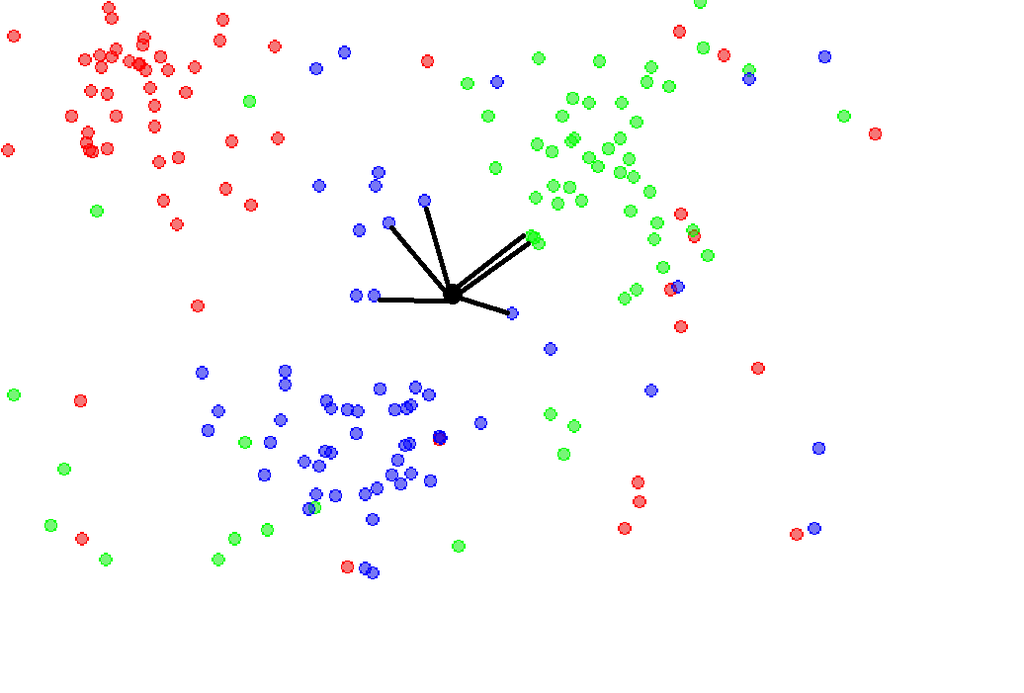

pairwise distances

## Hemming Metric

Hemming metric can represent similarity and distance between two entities based on their common inclusions

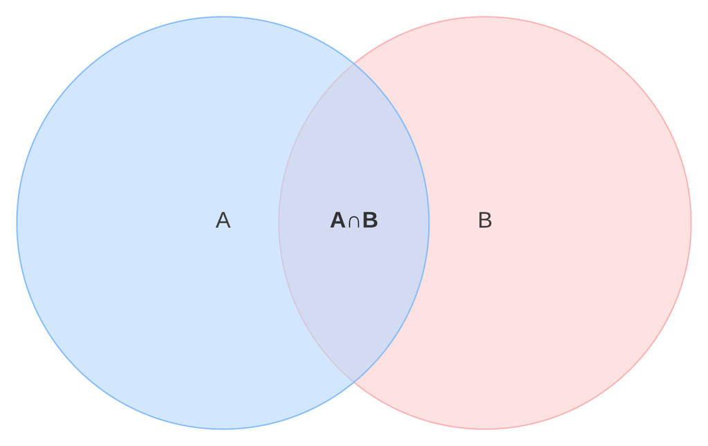

Hemming Metric

\[D_{Hemming} = 1.0 - n(A \cap B) / n(A \cup B) \]

## Metrics have a trend (time-series)

- Metric values are dynamic (time-dependant)

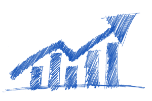

## Dynamic metrics

- Periodic/Historic Aggregated Similarities: last *n* days/weeks/months (Sliding/Cumulative Aggregated Windows)

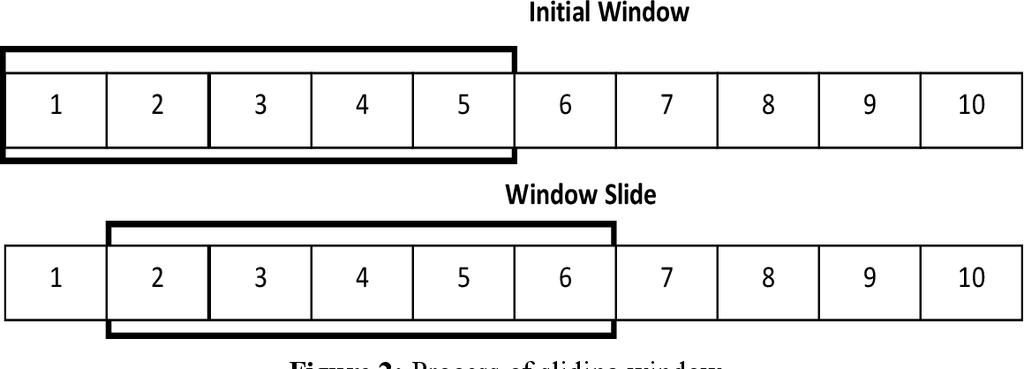

timeline sliding window

## Multi-dimensional Scaling

*N* cities, we know pairwise distances, find locations

*Input:* Symmetric square matrix of pair-wise distances

*Output:* Coordinates in n-dimensional space

## Benefits of Multi-dimensional Scaling :

- Run clustering algorithms like K-Means
- Helps visualizing them
- Create features from similarity metrics and use them in Supervised Learning techniques (Virtual Similarity Features)